# JMX805059 71..88

Converted from PDF `Panagopoulos-SalesForceDownsizingRisk-2018-JM.pdf` · 19 pages · anchors: page `#pN`, block `#pN-bK`

Page 1

Article

Sales Force Downsizing and Firm- Idiosyncratic Risk: The Contingent Role of Investors’ Screening and Firm’s Signaling Processes

#### Nikolaos G. Panagopoulos, Ryan Mullins, and Panagiotis Avramidis

Abstract Although sales force downsizing represents a challenging marketing resource change that can signal uncertainty about future firm performance, little is known about its impact on financial-market performance. Drawing from information economics, the authors address this knowledge gap by developing a comprehensive framework to (1) examine the impact of the size of a firm’s sales force downsizing on firm-idiosyncratic risk, (2) uncover investors’ screening processes that influence this relationship, and (3) identify firms’ mitigating signaling processes that can alleviate investor uncertainty linked to downsizing. The authors draw from several secondary sources to assemble a longitudinal data set of 314 U.S. public firms over 12 years and model their framework using a robust econometric approach. Findings show that larger sales force reductions are associated with greater firm-idiosyncratic risk. Furthermore, this increase in risk is amplified when firms face high levels of future competitive threats and lack transparency in financial reporting. However, chief executive officers can mitigate these deleterious moderating effects by signaling a commitment to growth (i.e., increasing advertising expenditures) and formally communicating an external strategic focus to Wall Street.

Keywords sales force downsizing, firm risk, investors, chief executive officer, information economics

Online supplement: https://doi.org/10.1177/0022242918805059

The sales force is among a firm’s most significant resources given its strong influence on customer relationships (Palmatier et al. 2006) and future profitability (Kumar, Sunder, and Leone 2014). Accordingly, the sales force constitutes a critical driver of current and future cash flows—strong signals of firm value to investors (Srivastava, Shervani, and Fahey 1998). Despite these inherent links between salespeople and firm value, little is known about the financial-market value of strategic decisions that affect the sales force, such as sales force downsizing. This knowledge gap is surprising given that salespeople are consistently one of the top positions laid off each quarter (Bureau of Labor Statistics 2013). Indeed, empirical research on the link between sales force downsizing and financial-market performance has been remarkably scant (see Table 1.1, Web Appendix 1). Specifically, three notable research gaps remain unaddressed.

First, current decision frameworks for sales force downsizing have examined operational outcomes, such as costs or profits (e.g., Zoltners, Sinha, and Lorimer 2018), with little focus

on financial-market performance. This is an important distinction, given prior work showing that downsizing increases customers’ uncertainty (Homburg, Klarmann, and Staritz 2012), which can lead to vulnerability in cash flows. Similarly, when sales force layoffs occur, investors’ uncertainty grows, owing to their limited knowledge regarding the firm’s ability and intentions to secure future cash flows, thus increasing firmspecific risk.

Second, although the extant literature has contributed a great deal of insight into the marketing–finance interface, there is still a limited understanding of how investors evaluate

Nikolaos G. Panagopoulos is the O’Bleness Associate Professor of Marketing and Director of Executive Education & International Sales at Ralph and Luci Schey Sales Centre, College of Business, Ohio University (email: npanag@ohio.edu). Ryan Mullins is Associate Professor of Marketing, College of Business, Clemson University (email: rmullin@clemson.edu). Panagiotis Avramidis is Assistant Professor of Finance, ALBA Graduate Business School, The American College of Greece (email: pavramidis@alba.acg.edu).

Journal of Marketing 2018, Vol. 82(6) 71-88 ª American Marketing Association 2018

Article reuse guidelines: sagepub.com/journals-permissions DOI: 10.1177/0022242918805059

journals.sagepub.com/home/jmx

Page 2

firm marketing actions. This knowledge gap is significant because the information available to investors strongly influences their interpretation of the impact of the firm’s marketing actions on firm value. Indeed, Srinivasan and Hanssens (2009) emphasize the importance of understanding how investors evaluate marketing actions that influence firms’ cash flows. Moreover, prior literature has shown that information surrounding layoffs has a major influence on investors (Datta et al. 2010), thus reinforcing the need to identify which investor information cues influence the relationship between sales force downsizing and firm risk.

Finally, recent research has highlighted the need for more managerially relevant factors to improve leaders’ influence on firm value (Hanssens, Rust, and Srivastava 2009). This is clearly evidenced as many chief executive officers (CEOs) struggle to provide a positive outlook for investors during sales force layoffs. For example, despite the CEO’s promises of improved performance, sales force layoffs at Pfizer were still perceived with skepticism (Edwards 2011). Managers thus need an expanded toolbox to leverage firm-related factors that influence the relationship between sales force downsizing and investors’ uncertainty.

We address these research gaps by conceptualizing the size of a firm’s sales force downsizing (i.e., the extent of planned reductions to a firm’s sales force) as a signal of market risk information that influences investors’ uncertainty regarding a firm’s future performance. Accordingly, we examine the influence of sales force downsizing on firm-idiosyncratic risk. We focus on idiosyncratic risk for three reasons. First, we expect that investors’ interpretation of sales force downsizing will vary, owing to investors’ imperfect information. Thus, firmidiosyncratic risk, a second-order statistic of stock returns, represents a clear overall measure of investors’ uncertainty, which stems from the differing signal interpretations.<sup>1</sup> Second, we draw on information economics as the theoretical foundation of our work. Idiosyncratic risk is particularly relevant in this context, given risk’s interpretation as a measure of stock price informativeness (Ferreira and Laux 2007). Third, firmidiosyncratic risk represents a key metric that is widely followed by managers, financial analysts, and investors (Bharadwaj, Tuli, and Bonfer 2011), and it accounts for up to 80% of total stock risk (Srinivasan and Hanssens 2009).

We build from information economics (e.g., Mizik 2010; Stiglitz 2000) to identify two mechanisms—screening and signaling—to contextualize the link between the size of a firm’s sales force downsizing and firm-idiosyncratic risk. These processes help us understand how investors evaluate the risk linked to sales force downsizing and provide managerial strategies to buoy investors’ outlooks even while signaling potential losses of customer relationships.

We draw from a variety of secondary sources to assemble a longitudinal data set of 314 U.S. public firms over 12 years and model our framework using a robust econometric approach. Our findings indicate that larger reductions in the sales force are associated with greater investor uncertainty as evidenced by increased firm-idiosyncratic risk. Furthermore, we illustrate that investors’ screening cues, such as a “firm’s product market fluidity” (the degree of future competitive threats a firm faces in its product markets; Hoberg, Phillips, and Prabhala 2014) and a “firm’s accruals management” (the degree of a firm’s earnings management; Hutton, Marcus, and Tehranian 2009), amplify the harmful link between downsizing and firmidiosyncratic risk. Our findings also show the beneficial effects of a firm’s mitigating signaling cues through the “firm’s advertising intensity” (the level of advertising targeted to a firm’s customers; Rubera and Kirca 2012) and the “CEO’s external focus” (the amount of executive attention devoted to entities outside the firm, such as customers and competitors; Yadav, Prabhu, and Chandy 2007). These latter cues provide C-suite leaders with strategies to weaken the link between downsizing and idiosyncratic risk, in light of harmful screening cues, by signaling greater firm quality and clearer intentions.

Our research makes several contributions. First, we offer the first study that links sales force downsizing to increases in investor uncertainty. This is especially salient given recent work highlighting that “understanding how marketing actions . . . can affect the risk profile of the firm is crucial” (Thomaz and Swaminathan 2015, p. 64). Accordingly, we provide greater guidance for marketing resource changes and subsequent firm-risk valuations. In addition, by providing theory to account for investor uncertainty, we extend prior downsizing studies that focus on customer uncertainty (Homburg, Klarmann, and Staritz 2012).

Second, we draw on information economics to conceptualize and test the measures investors use to screen firms, which are novel to marketing. Specifically, a firm’s product market fluidity is reflective of future market share, making it distinct from measures of static competition, such as the Herfindahl– Hirschman index (see Hoberg, Phillips, and Prabhala 2014). We show that product market fluidity increases investors’ uncertainty during sales force downsizing. Furthermore, our inclusion of a firm’s accruals management not only is new to marketing but also helps illustrate the “investor community as a customer” (Hanssens, Rust, and Srivastava 2009, p. 115). Specifically, we posit that insufficient information in financial reporting prevents investors from making optimal capital allocation decisions. As a result, marketing resource changes (e.g., layoffs) may be misinterpreted because investors are not receiving enough information about the firm’s intentions. Our results confirm this contention, showing that firms’ use of greater accruals management during sales force layoffs heightens investors’ uncertainty.

Third, whereas prior downsizing studies have shown that firm-controlled factors, such as open communication (Homburg, Klarmann, and Staritz 2012), can help improve operational performance, we lack strategic moderators that can

1 Given that investors’ interpretation of the downsizing signal may not necessarily be unanimous, the use of stock returns cannot capture the resulting variability in interpretation. We thank the area editor and two anonymous reviewers for contributing this insight.

72 Journal of Marketing 82(6)

Page 3

improve financial-market performance outcomes (see Table 1.1, Web Appendix 1). Our focus on the firm’s mitigating signaling cues helps illustrate how to reduce investor uncertainty through (1) advertising, which provides a quality signal during sales force downsizing and (2) CEO external focus, which plays a key role in both signaling a CEO’s strategic intentions and clarifying the reasoning behind layoffs.

#### Conceptual Framework

#### Theoretical Background

As a critical marketing resource change, we view the size of a firm’s sales force downsizing as a market information signal that can create uncertainty for external parties. We thus anchor our study in two key tenets of information economics: (1) information asymmetry, and (2) screening and signaling processes. We elaborate on these two tenets next.

Information asymmetry. Exchange parties often have differing amounts of information, creating information asymmetry (Stiglitz 2000). In our study, information asymmetry occurs because a firm, compared with investors, has more and better information regarding a decision to downsize the sales force. We expect that investors’ lack of information can trigger their uncertainty regarding a firm’s future financial outlook, thereby increasing firm-idiosyncratic risk. We also expect that information asymmetry makes it difficult for investors to evaluate the unobservable attributes of a firm’s “quality” and “intentions” related to the size of sales force downsizing.

In information economics, quality refers to the unobservable ability of the more informed party to fulfill the needs of an outsider (Connelly et al. 2011). Because an investor’s primary need relates to wealth maximization through investing in firms that yield positive financial outcomes, here we view quality as the unobservable ability of the firm to effectively compete in the market. Investors are also concerned about the firm’s future intentions (Connelly et al. 2011; Stiglitz 2000). In our context, investors are concerned with the firm’s intentions to downsize and whether this action maximizes their future wealth. To resolve uncertainty about the unobservable attributes of quality and intentions, two remedial, information-based processes can take place: screening and signaling (Mizik 2010; Stiglitz 2000).

Screening and signaling processes. Screening, which is enacted by the least informed party, occurs when investors vigilantly scan the environment to collect and examine observable cues that help to draw inferences about a firm’s quality or intentions (Connelly et al. 2011). Because investors desire to minimize the risk associated with their investments, they search for signals of the firm’s quality to increase their certainty regarding the firm’s future prospects (Raithel et al. 2012). We consider a firm’s product market fluidity as an observable cue reflecting firm quality. Because a firm’s product market fluidity captures changes in rival firms’ products relative to its own products (Hoberg, Philips, and Prabhala 2014), the construct constitutes a forward-looking measure of the potential competitive threats a

firm faces, rather than current or historical threats (Boone, Floros, and Johnson 2016). As such, firm product market fluidity reflects the firm’s ability to compete in the market against potential competitive threats and thus fulfill investors’ demands.

In addition, because managers might engage in deceitful behavior when information asymmetry is present (Connelly et al. 2011; Devers et al. 2007), investors will look for information that indicates the firm’s intentions. We consider the degree of a firm’s financial disclosure as an observable cue of the firm’s propensity to obscure its intentions. Specifically, prior evidence has indicated that a firm’s accruals management—delaying the recognition of losses to increase net income, or vice versa—can indicate management’s propensity to hide information about firm fundamentals from capital markets, thus clouding investors’ ability to ascertain the true state of future cash flows (Hutton, Marcus, and Tehranian 2009). Consequently, greater use of accruals management should hinder investors’ screening of the firm’s intentions about future plans and prospects in light of downsizing, thus leading investors to form different opinions about future firm performance (e.g., Devers et al. 2007).

Signaling, which is enacted by the more informed party, occurs when a firm projects cues to reduce investors’ uncertainty related to the firm’s imperceptible quality and intention attributes (Connelly et al. 2011; Devers et al. 2007). Unlike screening cues, signaling cues must be credible to help investors separate firms that truly possess the attributes of high quality and transparent intentions from “impostor” firms. A signal is credible when it is both observable and costly for other firms to imitate (Connelly et al. 2011). Observability refers to the extent to which investors see relevance in and can detect the emitted signal. Cost reflects the notion that some firms are in a better position than others to absorb the costs associated with a particular signal. Thus, lower-quality firms or those that do not have strong intentions cannot emit “false” signals for fear of losing credibility among investors or receiving legal class actions (Saboo and Grewal 2013).

We consider signals of the unobservable attributes of firm quality and intent that satisfy the criterion of credibility. First, we consider a firm’s advertising intensity as a highly visible quality signal that provides information about the firm’s ability to effectively compete in the market, thus attracting investors’ attention. Conceptually, advertising intensity parallels the firm’s product market fluidity in the screening process in that both reflect the firm’s ability to address competitive actions in the marketplace. For example, prior work has found that advertising spending gives investors a signal of the firm’s future financial well-being and competitive viability because advertising is a major contributor to a firm’s effort to build brand equity, appropriate value from customers, and differentiate from competition (Gao et al. 2015; Srivastava, Shervani, and Fahey 1998). Indeed, prior studies have shown that investors tend to favor stocks with recognized brand names built from advertising activity (Frieder and Subrahmanyam 2005). In addition, because cash flow shortfalls are associated with lower levels of future investment in advertising (Minton and Schrand

Panagopoulos et al 73

Page 4

1999), it is costly for firms with lower cash flow to imitate their highly capable counterparts.

Second, regarding a firms’ intent signals, we consider CEO external focus because it offers investors an observable cue of senior managers’ strategic emphasis (Yadav, Prabhu, and Chandy 2007). We draw CEO external focus from the 10-K reports submitted to the Securities and Exchange Commission, which requires that all statements are certified by the CEO. As such, CEO external focus is both visible and costly to imitate because 10-Ks (1) reflect observable attributes to the investor community (Zhang and Wiersema 2009) and (2) are formal documents that require board approval, thus making it costly for low-quality firms to emit such signals.

#### Conceptual Framework Overview

Our conceptual framework (Figure 1) builds directly from the aforementioned tenets. First, we expect that the size of a firm’s sales force downsizing represents a market-information signal that influences firm-idiosyncratic risk. Second, we identify cues that fall under each contingency process: (1) investors’ screening process and (2) the firm’s mitigating signaling process. We expect that cues related to the screening process will moderate the influence of the size of a firm’s sales force downsizing on firm-idiosyncratic risk (i.e., two-way interactions), and we posit that the firm enacts a signaling process that mitigates the interactive effects of the screening process with the size of a firm’s sales force downsizing on firm-idiosyncratic risk (i.e., three-way interactions). Next, we delineate the specific hypotheses in our conceptual framework.

#### Hypothesis Development

Size of a firm’s sales force downsizing and firm-idiosyncratic risk. Investors incorporate information about important marketing resource changes (e.g., sales force downsizing) that affect the future outlook of the firm (see Hanssens, Rust, and Srivastava 2009). However, firms often have more information than investors about these changes, creating an information asymmetry that increases investors’ uncertainty about the firm’s ability and intentions to create value for them, thus resulting in markets with higher stock volatility (Srinivasan and Hanssens 2009). As such, idiosyncratic risk reflects volatility in stock returns that result from firm-specific actions, thereby representing investors’ uncertainty regarding future cash flows (Bharadwaj, Tuli, and Bonfer 2011). Accordingly, we expect that larger sales force downsizing increases investors’ uncertainty and thus increases firm-idiosyncratic risk as a result of increased volatility and vulnerability of future cash flows.

Specifically, prior work has illustrated that the volatility and vulnerability of cash flows increases when a firm’s customer relationships are destabilized (Srivastava, Shervani, and Fahey 1998). This suggests that strong customer relationships create competitive barriers that can insulate a firm’s cash flows from competition. Although firms can employ a

variety of means to acquire and retain customers, the sales force constitutes a vital marketing resource in this context. Specifically, because the sales force represents the primary vehicle through which many firms interact with customers (Palmatier et al. 2006), customer relationships may be severed after larger cuts to the sales force, thus leading to cash flow volatility. In addition, laying off a larger number of salespeople may damage customers’ satisfaction (Habel and Klarmann 2015) or increase customers’ relationship uncertainty (Homburg, Klarmann, and Staritz 2012) because the firm has fewer salespeople to call on customers. Consequently, larger sales force reductions should increase investors’ uncertainty regarding the firm’s ability to satisfy customers. Finally, larger cuts in the sales force increase the workload for “surviving” salespeople, thus making new customer acquisition increasingly difficult (Colletti and Chonko 1997). Taken together, these arguments suggest that investors view larger sales force reductions as a threatening signal to the stability and predictability of future cash flows, thus leading to higher firm-idiosyncratic risk.

H1: The larger the size of a firm’s sales force downsizing, the larger the increases in firm-idiosyncratic risk.

Investors’ quality-screening process. As mentioned previously, larger reductions in sales force size increase firmidiosyncratic risk due to investors feeling uncertain about the stability and predictability of future cash flows. This suggests that factors that influence investors’ uncertainty regarding a firm’s cash flows should influence the effects of sales force downsizing on risk. We expect that higher levels of a firm’s product market fluidity amplify the uncertainty of future cash flows signaled by larger reductions in the sales force, thus further increasing firm-idiosyncratic risk. In particular, because fluidity relates to changes in a firm’s product space owing to moves made by the firm’s competitors, it captures the extent to which a firm faces rapid changes in its product market (Hoberg, Phillips, and Prabhala 2014). Thus, compared with firms facing lower product market fluidity, firms with higher levels of product market fluidity signal an inability to maintain the superiority of their products relative to current and emerging rivals’ offerings and, thus, differentiate themselves from competition. This vulnerability to competitive actions should increase the volatility of a firm’s future cash flows and prompt greater investor uncertainty regarding a downsizing firm’s economic future. In other words, higher levels of future product market competition serve as an observable cue that amplifies investors’ uncertainty that stems from larger sales force reductions, thereby strengthening and solidifying their disbelief in the downsizing firm’s ability to ward off competitive threats or generate demand. In summary, for firms with higher levels of product market fluidity, larger sales force reductions are more likely to cause greater investor uncertainty regarding downsizing firms’ ability to secure future cash flows and, therefore, increase firm-idiosyncratic risk.

74 Journal of Marketing 82(6)

Page 5

H2: The higher a firm’s product market fluidity, the stronger the positive effect of the size of a firm’s sales force downsizing on firm-idiosyncratic risk.

Firms’ mitigating quality-signaling process. We posit that a firm’s advertising intensity reduces information asymmetry by helping a firm signal its ability to effectively compete in the market and separate itself from competition. Our expectation draws on the work of Joshi and Hanssens (2009), who point out that advertising intensity influences investors through a quality-signaling mechanism: increased levels of advertising signals a firm’s financial well-being or competitive viability to investors. Indeed, prior work has established advertising’s positive moderating impact on stock market responses to firm events (see Gao et al. 2015). We therefore anticipate that advertising intensity can enact a quality-signaling process to counteract the qualityscreening process that occurs when firms downsize the sales force under higher product market fluidity. Specifically, the heightened information asymmetry emanating from larger sales force reductions motivates investors to look for proactive, firminitiated signals to alleviate their concerns regarding the firm’s future earnings. As noted in H2, however, higher product market fluidity should cause investors to experience greater uncertainty regarding downsizing firms’ ability to secure future cash flows, thereby increasing firm-idiosyncratic risk. But when a firm increases advertising expenditures, investors may interpret the action as a positive signal that larger sales force reductions do not threaten the firm’s ability to compete in the future. Rather, increased advertising signals the firm’s competitive viability and

commitment to growth (e.g., Joshi and Hanssens 2009) and should, therefore, decrease investors’ uncertainty regarding the firm’s ability to counter competing product entries and secure future cash flows. In summary, we expect that improving investors’ confidence in the firm’s quality through increased advertising spending should reduce the information asymmetry regarding larger sales force reductions amid higher firm product market fluidity, thus reducing firm-idiosyncratic risk.

H3: The positive moderating effect of a firm’s product market fluidity on the relationship between the size of a firm’s sales force downsizing and firm-idiosyncratic risk is weakened at higher levels of firm’s advertising intensity.

Investors’ intent-screening process. Drawing from the notion of screening explained previously, we also expect that investors will screen for firms’ strategic intentions to reduce their uncertainty regarding the influence of the size of a firm’s sales force downsizing on future cash flows. Specifically, firms possess private information about the reasoning for strategic decisions such as sales force layoffs (Connelly et al. 2011). This suggests that investors’ uncertainty of the firm’s intentions to secure future cash flows should also influence the effects of sales force downsizing on risk. Accordingly, we expect that the heightened information asymmetry created by larger sales force downsizing will motivate investors to ascertain the intentions surrounding the reductions (e.g., boosting short-term profits, restructuring to meet long-term needs) by closely examining the firm’s financial reports. However, a firm’s use of accruals

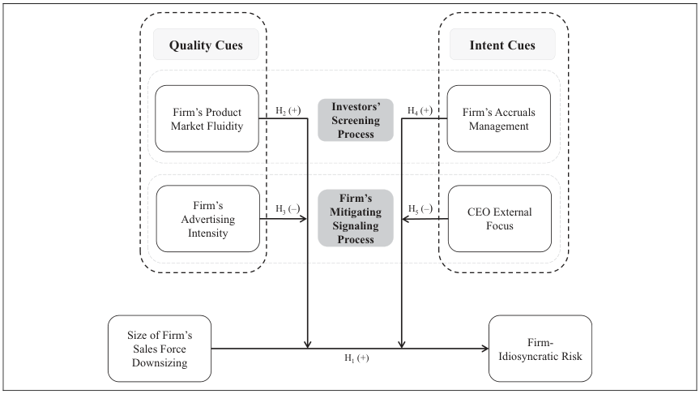

NOTE: figure/graphic rendered as an image from the PDF; its content is not machine-readable text. Caption (if any) follows as the next block.

**text found inside the figure**

Size of Firm’s

Sales Force Downsizing

Firm- Idiosyncratic Risk

Firm’s Product Market Fluidity

Firm’s Accruals

Management

Firm’s Advertising

Intensity

CEO External

Focus

**Quality Cues Intent Cues**

**Investors’ Screening**

**Process**

**Firm’s Mitigating**

**Signaling**

**Process**

H1 (+)

H2 (+)

H3 (–)

H4 (+)

H5 (–)

Figure 1. Conceptual framework.

Panagopoulos et al 75

Page 6

management—delaying the recognition of losses to increase net income, or vice versa (Hutton, Marcus, and Tehranian 2009)—can cloud investors’ ability to ascertain the current state of cash flows or to discern how future cash flows will be secured following larger reductions in the sales force. This type of earnings smoothing (i.e., less transparency for investors) makes it more likely that investors will be unable to discern the firm’s intentions for future cash flows in light of downsizing. As a result, the firm’s use of discretionary accruals is more likely to produce differences in opinion about the firm’s future earnings and stock prices (Hutton, Marcus, and Tehranian 2009). In other words, higher use of accruals management serves as an observable cue that increases investors’ uncertainty regarding the firm’s intentions to secure future cash flows following larger sales force cuts, thus further increasing firm-idiosyncratic risk.

H4: The greater a firm’s use of accruals management, the stronger the positive effect of the size of a firm’s sales force downsizing on firm-idiosyncratic risk.

Firms’ mitigating intent-signaling process. We expect that CEO external focus reduces the information asymmetry between a firm’s top management and investors by helping firms signal their intentions to effectively compete in the market and, thus, secure future cash flows. Specifically, top management plays an important role in communicating the firm’s strategy and viability of plans to investors (e.g., Saboo and Grewal 2013). Although firms communicate with investors through many means, 10-Ks represent an important vehicle CEOs employ to communicate their attentional focus on specific entities such as customers or competition and to elaborate on firm intentions (Osborne, Stubbart, and Ramaprasad 2001). The information contained in these reports, regarding the firm’s focus, represents an unobtrusive manifestation of organizational strategic intent and mindset, which helps investors evaluate the firm’s future prospects (Saboo and Grewal 2013). In particular, an external focus implies high levels of firm preparedness in terms of formulating and implementing strategic actions designed to cater to customer needs or defend against competitive threats (Yadav, Prabhu, and Chandy 2007). In this way, external focus can help investors interpret the intent of larger sales force reductions as a long-term strategy that takes emerging customer needs and competition into account. This improved understanding of the firm’s plan to create value should help resolve uncertainty stemming from accruals management by strengthening confidence in the firm’s intentions to leverage downsizing for future investor wealth. Accordingly, we expect that greater CEO external focus will counteract the intentscreening process that occurs when firms downsize their sales force under high levels of accruals management and, thus, will mitigate investors’ uncertainty regarding future cash flows. In summary, we expect that increases in firm-idiosyncratic risk— as a result of larger sales force reductions under higher levels of accruals management—will be lowered for firms with greater CEO external focus.

H5: The positive moderating effect of a firm’s accruals management on the relationship between the size of a firm’s sales force downsizing and firm-idiosyncratic risk is weakened at higher levels of CEO external focus.

#### Data

#### Data Sources

Consistent with recent firm-level sales force research (Lee, Sridhar, and Palmatier 2017), our sampling frame comprises a list of U.S.-based, publicly traded firms with the largest sales forces that is reported by Selling Power magazine. We assemble data for these firms from a variety of secondary sources (see Table 1).

First, to formally test our hypotheses, we estimate our independent variable (i.e., size of a a firm’s sales force downsizing) using the annual sales force size data reported in Selling Power magazine, which employs a multiple-informant data collection approach.<sup>2</sup> Second, we take an additional estimate of the independent variable from two official mechanisms for transmitting firm information to investors (Osborne, Stubbart, and Ramaprasad 2001; Zhang and Wiersema 2009): firms’ annual reports to shareholders (drawn from Mergent Archives) or 10-Ks<sup>3</sup>

(drawn from EDGAR, Morningstar, and firms’ websites). We use this second estimate to verify the veracity of the Selling Power data (see the “Independent Variable” subsection) as well as the robustness of our hypothesis testing results to a different data source (see the “Results” section). Third, daily stock price data for computing annual firm-idiosyncratic risk are supplied from the Center for Research in Security Prices. Fourth, data on firms’ product market fluidity come from the Hoberg and Phillips Data Library. Fifth, we obtained data on CEO external focus from textual analysis of the Management Discussion and Analysis (MD&A) section of firms’ 10-Ks. Finally, we use annual financial data from COMPUSTAT’s Fundamentals Database to compute firms’ accruals management, firms’ advertising intensity, and firm- and industry-level covariates.

Our primary objective is to model investors’ reactions to information regarding firms’ sales force size. Because firms publish their annual reports to shareholders (or file 10-Ks for the year) a few months before Selling Power’s release date, it is possible that information on sales force size reaches investors before that date. Accordingly, to establish the time alignment between information on sales force downsizing and investors’ reactions, we set the annual report publication date (or 10-K filing date) as the publication date of reference in our operationalization of both the independent and dependent variables (discussed subsequently).

2 According to Gerhard Gschwandtner (Selling Power’s founder/CEO), Selling Power connects with firms at multiple levels (e.g., human resources, communications, Vice President of Sales) to get the most accurate data on sales force sizing counts (email communication on April 6, 2017; available upon request). 3 We employ a firm’s 10-K report whenever an annual report is not available.

76 Journal of Marketing 82(6)

Page 7

#### Sample

Our main analysis is based on a cross-sectional time series (panel) data set representing 2,349 firm-year observations from 314 firms over a period of 12 years (2001–2012) to account for different cycles in the U.S. economy (for sample composition, see Table 2.1, Web Appendix 2). Our panel is unbalanced in that we do not have complete data available for all firms over the entire 12-year period and across all data sources. Thus, following previous work (e.g., Kim and McAlister 2011), we employ different sample sizes across estimated models.

#### Independent Variable

We estimate the size of a firm’s sales force downsizing using the data reported in Selling Power. We operationalize our independent variable as the percentage change (absolute value<sup>4</sup>) in sales force size between the year of the publication date (year t) and the year that precedes that date (year t 1), over the sales force size at year t 1, when we observe a sales force reduction

(i.e., negative change). For firm-year observations with sales force upsizing (i.e., positive change) or no change, we set the downsizing variable equal to zero.

By construction, this operationalization compares firms that downsized with firms that upsized or made no change in their sales force. However, after we conducted a simultaneous test of downsizing versus upsizing versus no-change, using a spline specification (Greve 2003) that measures the effect of each sales force sizing group separately, we concluded that upsizing and no change have different effects on firm-idiosyncratic risk (see “Additional Analysis: The Impact of Sales Force Upsizing” subsection for details). Thus, upsizing and no change should not be grouped together. Accordingly, we exclude the firm-year observations with sales force upsizing from the main analysis to isolate the effect of downsizing.

Furthermore, we implement two verification tests to assess the information availability to investors and veracity of our independent variable that relies on Selling Power data.<sup>5</sup> First, we create a second estimate of the independent variable by

Table 1. Variables, Measures, and Data Sources.

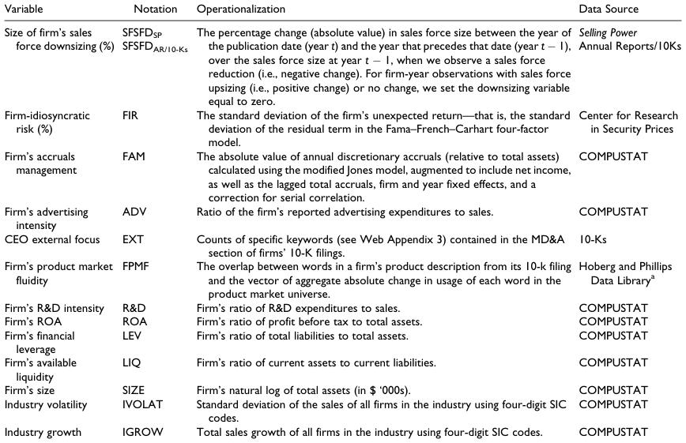

NOTE: complex table shown as an image of the PDF; the text below is a rough machine extraction and may be mis-aligned.

**extracted text (unreliable layout)**

ahttp://hobergphillips.usc.edu/.

4 We use the absolute value (i.e., exclusion of the negative sign) of change to facilitate the interpretation of the results.

5 We are thankful to the area editor and one anonymous reviewer for their insightful suggestions on this topic.

Panagopoulos et al 77

Page 8

Table 2. Variable Intercorrelations.

1 2 3 4 5 6 7 8 9 10 11 12 13 14 15

1. FIR 2. SFSFDSP .126***

3. SFSFDAR/10-Ks .143*** .726***

4. FPMF .113*** .020 .068***

5. FAM .262*** .074*** .090*** .127***

6. EXT .017 .043** .078*** .112*** .014

7. ADV –.091*** –.011 –.001 –.002 –.013 .080***

8. R&D .013 .040* .064*** .431*** .108*** .143*** –.007

9. ROA –.413*** –.096*** –.112*** –.069*** –.027 –.008 .157*** –.013

10. LEV .189*** –.015 –.030 –.156*** .061** –.125*** .040** –.291*** –.148***

11. LIQ –.029 .034* .056*** .105*** .033 .057*** –.067*** .226*** .144*** –.552***

12. SIZE –.409*** –.105*** –.111*** .180*** –.151*** –.006 .133*** .130*** .079*** .088*** –.185***

13. IVOLAT –.154*** –.032 –.042** –.418*** –.111*** –.072*** .079*** –.366*** .049** .086*** –.026 .036*

14. IGROW –.112*** –.039*** –.021 .031 –.006 –.001 .016 .015 .087*** –.041** –.003 .045** –.049**

15. IMSSFD .086*** .085*** .116*** .041* .056*** .079*** –.020 .025 –.032 –.034 –.031 –.125*** –.047** –.018

16. ISFSD –.055*** –.051** –.055*** .123*** –.022 –.066*** –.005 .133*** .075*** .011 –.040** .195*** –.096*** .001 –.114***

*p < .10. **p < .05. ***p < .01. Notes: We used two-tailed significance tests. FIR ¼ firm-idiosyncratic risk (%); SFSFDSP ¼ size of firm’s sales force downsizing from Selling Power (%); SFSFDAR/10-Ks ¼ size of firm’s sales force downsizing from

annual reports/10-Ks (%); FPMF ¼ firm’s product market fluidity; FAM ¼ firm’s accruals management; EXT ¼ CEO external focus; ADV ¼ firm’s advertising intensity; R&D ¼ firm’s research and development

expenditures to firm’s sales; ROA ¼ firm’s return on assets; LEV ¼ firm’s financial leverage; LIQ ¼ firm’s available liquidity; SIZE ¼ firm size; IVOLAT ¼ industry volatility; IGROW ¼ industry growth; IMSSFD ¼

industry’s mean size of sales force downsizing; ISFSD ¼ industry sales force size disclosure.

78

Page 9

employing the same operationalization and by using the size of a firm’s sales force reported in firms’ annual reports/10-Ks. The high correlation between the two estimates (see Table 2) suggests that the two sources essentially measure the same construct (Pearson’s r ¼ .726, p < .001). Second, we calculate the bivariate correlation between the sample firms’ total number of employees reported in COMPUSTAT and the total number of employees published in Selling Power (reported alongside sales force size). The high correlation between the number of employees given by the two sources suggests that the two sources almost overlap (Pearson’s r ¼ .910, p < .001). Because COMPUSTAT employee data is gauged to be a reliable data source (given its widespread adoption in prior work), we conclude that the employee data Selling Power collects is also reliable.

#### Dependent Variable

Our dependent variable is the idiosyncratic component of a firm’s stock daily return volatility. For every firm-year observation, we use the publication date of the annual report (or filing date of the 10-K) as the starting date and include all daily closing prices over the next 12 months following this date. Equation 1 provides the observed daily return:

ri; s ¼ ln½Pi; s=Pi; s 1; ð1Þ

where Pi,s is the closing price of firm i’s common stock at the end of day s and Pi, s 1 is firm i’s closing price at the end of previous day s 1 (prices are adjusted for capital changes such as stock splits and stock dividends).

We estimate the expected returns of the firm’s stock E(ri,s) using Fama–French–Carhart’s four-factor model (Srinivasan and Hanssens 2009), based on daily data from French’s website (http://mba.tuck.dartmouth.edu/pages/faculty/ken.french/data_ library.html). In particular, the expected stock return is the predicted value from the following regression model:

r i; s rf; s ¼ b0; i þ b1; iðrm; s rf; sÞ þ b2; i HMLs

þ b3; i SMBs þ b4; i UMDs þ ui; s; ð2Þ

where rf, s is the risk-free rate; rm, s is the value weighted return on all stocks listed on NYSE, AMEX, and NASDAQ; HML s is the book-to-market risk premium factor; SMB s is the sizebased risk premium factor; UMD s is the returns momentum factor; and ui, s is the residual term. Following Luo and Bhattacharya (2009), we define firm-idiosyncratic risk as the standard deviation of the firm’s unexpected return—that is, the standard deviation of the residual term in Equation 2.

#### Moderating Variables

Firm’s product market fluidity. We use data made available by Hoberg, Phillips, and Prabhala (2014). Specifically, they used a text-based algorithm that captures information from product descriptions of firms’ product spaces and rival moves contained in firms’ 10-Ks to measure firms’ product market

fluidity. The algorithm employed involves “measuring the overlap between words in a firm’s product description from its 10-K filing and the vector of aggregate absolute change in usage of each word in the product market universe” (Boone, Floros, and Johnson 2016, p. 110). Theoretically, the lowest value that a firm’s product market fluidity can get is zero, which indicates no potential competitive threats in its product markets, as such higher values indicate higher levels of competitive threats. We take the two-year moving average of this measure to match the timeframe of the other moderators.

Firm’s accruals management. To distinguish between unbiased and discretionary accruals, we employ the modified Jones model, augmented to include net income, as well as the lagged total accruals, firm and year fixed effects, and a correction for serial correlation (Kothari, Mizik, and Roychowdhury 2015). Specifically, we estimate the following fixed-effect first-order autoregressive model:

TAccruals it ¼ b0i þ jTAccruals it1 þ b1

1 Assets it1 þ b2ðD Sales it D Rec itÞ þ b3 PPE it þ b4 ROA it þ yt þ u it; ð3Þ

where TAccruals is income before extraordinary items minus cash flow from operating activities, adjusted for extraordinary items and discontinued operations and scaled by lagged total assets; 1/Assets is the inverse total assets of the firm reported in fiscal year t 1; DSales is the annual change in sales scaled by lagged total assets; DRec is the annual change in total receivables scaled by lagged total assets; PPE is the firm’s property, plant, and equipment scaled by lagged total assets; ROA is net income on lagged total assets; yt is year t effect; and uit is the residual term.

To control for year- and firm-specific effects that can induce model misspecification, we employ the estimation procedure proposed by Kothari, Mizik, and Roychowdhury (2015). In particular, each firm’s annual total accruals are subtracted from the cross-sectional mean for that year. Next, the deviation of each firm’s annual total accruals from the cross-sectional mean is subtracted from the corresponding deviation in the previous year. The explanatory variables in the model are also subtracted in the same manner. The estimation of the model yields a time series of residuals for each firm. We subtract from each firmyear residual the mean value of the residual across all years for the corresponding firm to obtain the discretionary accruals estimate.

According to Dechow, Sloan, and Sweeney (1995), the large, positive discretionary accruals recorded by firms are followed by large, negative discretionary accruals instead of the positive cash flow realizations that would tend to follow unbiased accrual practice. We therefore adopt the two-year moving average of the absolute value of annual discretionary accruals. The higher the accruals management, the more the firm is managing reported earnings, thus revealing less firmspecific financial information to investors.

Panagopoulos et al 79

Page 10

Firm’s advertising intensity. Given prior work showing a longterm, year-to-year carryover effect of advertising (Sethuraman, Tellis, and Briesch 2011), we measure a firm’s advertising intensity using a two-year moving average of the ratio of the firm’s reported advertising expenditures to sales (Rubera and Kirca 2012).

CEO external focus. We measure CEO external focus by using counts of specific keywords contained in the MD&A section of firms’ 10-K filings. We employed a multistage procedure. First, we collected 10-K filings<sup>6</sup> for each firm-year. Second, we trained two graduate research assistants on 10-K filings, software use, and the keyword dictionary developed by Yadav, Prabhu, and Chandy (2007) (see Web Appendix 3). Third, research assistants manually pulled out the MD&A sections from the 10-Ks. We employed a manual procedure because firms often incorporate the MD&A section by reference to an exhibit that is part of the filing but is often merged with other material, thus making automated parsing inaccurate. Finally, each MD&A file was imported into the Hermetic Word Frequency Counter Advanced software to automatically scan documents and record the frequency of keywords in our dictionary for each firm-year. All MD&A files and word counts were checked for accuracy by the first author and the two assistants. The final measure of CEO external focus is the ratio of keyword counts over the total number of words in the MD&A section, scaled by 1,000 (Eggers and Kaplan 2009). We take the two-year moving average of this ratio to match the timeframe of the other moderators.

#### Control Variables

We account for firm- and industry-specific variables in our analyses. With regard to firm-specific variables, leverage increases the volatility of earnings and stock returns; therefore, we control for firms’ financial leverage measured by the ratio of total liabilities to total assets. Stock prices are driven by the firm’s available liquidity, measured by the ratio of current assets to current liabilities. We control for the relationship of research and development (R&D) with firm risk by using the ratio of R&D expenditures to sales (R&D Intensity). Furthermore, a proportion of firms report R&D and advertising together under the same accounting item of other operational expenses. This creates two significant issues. First, missing data implies a large reduction in the sample size. Second, if R&D and advertising are not missing randomly (i.e., firms with high or low values tend not to report them separately), this would create selection bias. Thus, we follow recommendations in the extant literature (e.g., Luo and Bhattacharya 2009) and replace all missing values of R&D and advertising expenses with zero. To distinguish firms that do not separately report

these expenses from peers that do, we create two dummy variables—the R&D dummy and the ADV dummy—which take a value of one if R&D (or advertising) expenses were not reported and zero otherwise. These dummies capture any hidden effect of missing values as described previously. Moreover, because a firm’s earnings affect stock volatility, we take into account the firm’s profitability measured by the return on assets (ROA) ratio. Finally, Ferreira and Laux (2007) show that firm size has a negative relation with firm-idiosyncratic risk; we therefore control for firm size measured by the natural log of total assets (in thousands of dollars).

At the industry level, defined using the four-digit Standard Industrial Classification (SIC) scheme, we consider two covariates. Firm stock volatility is positively related to industry volatility (Campbell et al. 2001), whereas a firm’s earnings and stock returns are further driven by industry growth (Gruca and Rego 2005). We thus include industry volatility, gauged by the standard deviation of the sales of all firms in the industry, and industry growth, measured by the total sales growth of all firms in the industry. Table 2 provides variable intercorrelations (for summary statistics, see Table 4.1, Web Appendix 4). Variance inflation factors indicate no evidence of multicollinearity in our data (see Table 5.1, Web Appendix 5).

#### Method

#### Model Specification

We specify a panel data regression model to test hypotheses. Our model specification offers many benefits. First, to eliminate potential simultaneity bias, we employ one-period lagged covariates. Second, in addition to firm- and industry-specific covariates, we account for any unobservable firm-specific heterogeneity by applying a fixed-effects model at the firm level. Third, we account for time trends by adding year effects. Fourth, we use robust clustered estimates of errors (Wooldridge 2002) to curb possible biases of error heteroskedasticity and within-cluster (firm) correlation. Fifth, we include ROA as a covariate to address the firm-level endogeneity from firm financial performance that might affect the relationship between the size of a firm’s sales force downsizing and firmidiosyncratic risk. Sixth, to rule out alternative explanations due to major corporate events, we omit firms from our sample that were involved in consolidation (i.e., mergers/acquisitions), or restructuring (i.e., business closures/exits) during the study period. Finally, we winsorize the data at the 1st and 99th percentiles to curb the impact of spurious extreme values on our findings.

6 In some cases, the 10-K was not available, and thus we collected the 10-K405 filing, which is not different in substance from a 10-K (see https://help.edgaronline.com/edgar/formtypes.asp).

80 Journal of Marketing 82(6)

Page 11

FIR i; t ¼ g0 þ g1 SFSFD i; t þ g2ð SFSFD i; t FPMF i; t1Þ

þ g3ð SFSFD i; t FAM i; t1Þ þ g4ð SFSFD i; t FPMF i; t1 ADV i; t1Þ

þ g5ð SFSFD i; t FAM i; t1 EXT i; t1Þ þ g6 FPMF i; t1 þ g7 EXT i; t1 þ g8 FAM i; t1 þ g9 ADV i; t1 þ g10ð FPMF i; t1 ADV i; t1Þ

þ g11ð SFSFD i; t ADV i; t1Þ þ g12ð FAM i; t1 EXT i; t1Þ

þ g13ð SFSFD i; t EXT i; t1Þ þ Controls i; t1

where yt is year dummies’ effects, Yt is the set of mutually exclusive year dummies, Zi is time-invariant firm’s unobservable fixed effects, and ei, t is the error term.

#### Addressing Endogeneity

Firms experiencing financial troubles or undergoing transformations are more likely to downsize their sales force as part of cost management considerations. In this case, an increase in firm-idiosyncratic risk may be due to the additional uncertainty caused by the deterioration of firm fundamentals rather than to sales force downsizing. Alternatively, sales force downsizing may be caused by increased firm-idiosyncratic risk rather than the other way around. Although we exclude firm-year observations in which a major corporate event has taken place and control for the observed firm’s fundamentals and the timeinvariant unobserved firm-specific factors, there may be some unobserved time-varying variable that is omitted and could bias our results. Moreover, the sample includes only firms with available sales force data. Nonrandomly selected samples may lead to erroneous conclusions owing to sample selection bias in sales force downsizing. Accordingly, following Han, Mittal, and Zhang (2017), we address potential omitted-variable and sample selection biases by running two auxiliary regression models.

Control function approach. To address omitted-variable bias, we use the control function approach, in which a correction term is added to the regression model so that the potentially endogenous variable is no longer correlated with the error term (Han, Mittal, and Zhang 2017; Wooldridge 2002). In particular, we estimate an auxiliary regression of the endogenous variable (i.e., sales force downsizing) on an instrument, plus the exogenous controls. We draw from the extant literature (e.g., Budros 2000) to identify the instrument using industry-year categorization: the average size of sales force downsizing among peer firms in the industry (two-digit SIC). When

calculating the instrument, we omit the contribution of the focal firm, and therefore, the instrument varies across firms even within the same industry and year. Because the peerbased instrument is unlikely to be a determinant of the focal firm’s idiosyncratic risk and is correlated with sales force downsizing, the variable meets the conditions of a valid instrument (Wooldridge 2002). We fit the panel regression model in Equation 4 using the estimated residuals from this first auxiliary regression model as an additional covariate.

Selection bias. To address sample selection bias, we run a Heckman selection model using full information maximum likelihood. Specifically, we augment the firm-year observations in our data set with observations for firms listed in the major U.S. stock markets and for which we have no information about their sales force. Drawing on the augmented sample, we estimate an auxiliary probit model using the exogenous controls as well as an exclusion variable. We follow Han, Mittal, and Zhang (2017) and define the exclusion variable as the proportion of firms in the same industry (two-digit SIC) that disclose their sales force size. From this second auxiliary regression model, we calculate the inverse Mills ratio (i.e., the ratio of the estimated probability density function to the cumulative distribution function), which we include as an additional covariate to the panel regression model (Equation 4).

Because the control function residuals and the inverse Mills ratio included in the model are estimates rather than true values, we need to take this extra source of variation into account. Therefore, we follow Petrin and Train (2010) and correct the standard errors by bootstrapping simultaneously the auxiliary regressions (the control function and the Heckman selection) and the main model (Equation 4). Thus, reported standard errors of the coefficients are derived from 1,000 bootstrap samples.

#### Results

#### Auxiliary Regression Results

As shown in the Heckman selection model (see Table 6.1, Web Appendix 6), the industry’s percentage of firms that disclose their sales force is a significant predictor (g ¼ 4.659, p < .01) of the selection probability. Likewise, the control function model (Table 6.1, Web Appendix 6) shows that the average size of sales force downsizing among peer firms in the industry is positively associated with sales force downsizing (g ¼ 2.187, p < .05).

#### Hypothesis Testing Results

As mentioned previously, we offer two tests of our hypotheses. First, we formally test hypotheses by employing the size of a firm’s sales force downsizing estimate that draws on Selling Power data. Table 3 provides results for three models: Model 1 (covariates, main effect); Model 2 (covariates, main effect, two-way interactions); and Model 3 (covariates, main effect, two- and three-way interactions), which is the complete model

used to test our hypotheses. The incremental R<sup>2</sup> tests indicate that adding the proposed moderators and interaction terms improves the model’s explanatory power.

Consistent with our predictions in H1, we find that larger reductions in the sales force increase firm-idiosyncratic risk (g1 ¼ .076, p < .05). In support of H2, the two-way interaction of the size of a firm’s sales force downsizing with a firm’s product market fluidity is positive and significant (g2 ¼ .075, p < .01), indicating that firms with larger sales force reductions under highly competitive product market conditions experience a stronger positive impact on their idiosyncratic risk. In support of H3, the effect of the three-way interaction between the size of a firm’s sales force downsizing, the firm’s product market fluidity, and the firm’s advertising intensity is negative and

significant (g3 ¼ –.100, p < .01). Thus, although a firm’s product market fluidity amplifies the positive influence of the size of a firm’s sales force downsizing on firm-idiosyncratic risk, this influence is mitigated by advertising intensity. As predicted in H4, we find that the effect of the two-way interaction between the size of firm’s sales force downsizing and a firm’s accruals management on firm-idiosyncratic risk is positive and significant (g4 ¼ .149, p < .01). In other words, accruals management amplifies the positive influence of the size of a firm’s sales force downsizing on firm-idiosyncratic risk. Finally, in support of H5, we find that the effect of the three-way interaction between the size of a firm’s sales force downsizing, accruals management, and CEO external focus is negative and significant (g5 ¼ –.101, p < .05). Thus, although a

Table 3. Hypothesis Testing Results (Based on Selling Power Data): Ordinary Least Squares Fixed-Effects Regression Models of Firm- Idiosyncratic Risk.

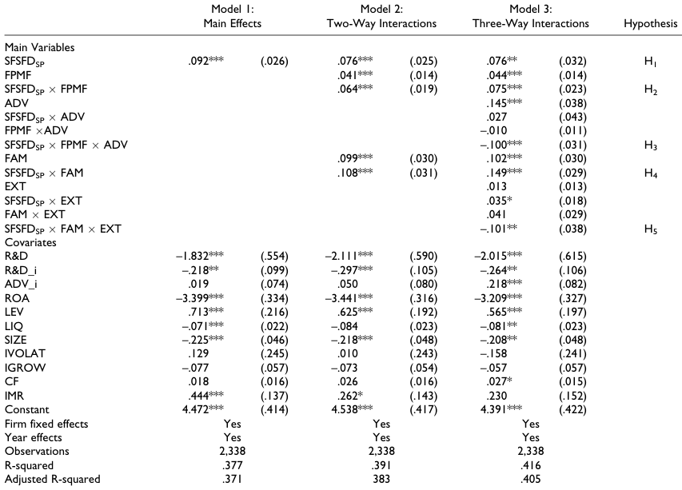

NOTE: complex table shown as an image of the PDF; the text below is a rough machine extraction and may be mis-aligned.

**extracted text (unreliable layout)**

*p < .10. **p < .05. ***p < .01. Notes: We used two-tailed significance tests. The first entry within each cell corresponds to estimated coefficients, followed by robust standard errors in parentheses. Reported effects for the main variables are standardized to facilitate interpretation of interaction effects. SFSFDSP ¼ size of firm’s sales force downsizing from Selling Power (%); FPMF ¼ firm’s product market fluidity; ADV ¼ firm’s advertising intensity; FAM ¼ firm’s accruals management; EXT ¼ CEO external focus; R&D ¼ firm’s research and development expenditures to firm’s sales; R&D_i ¼ firm’s research and development dummy; ADV_i ¼ firm’s advertising dummy; ROA ¼ firm’s return on assets; LEV ¼ firm’s financial leverage; LIQ ¼ firm’s available liquidity; SIZE ¼ firm size; IVOLAT ¼ industry volatility; IGROW ¼ industry growth; CF ¼ residual term of control function model; IMR ¼ inverse Mills ratio estimated using Heckman’s selection model.

firm’s accruals management amplifies the positive influence of the size of a firm’s sales force downsizing on firm-idiosyncratic risk, this influence is mitigated by CEO external focus.

Second, we conduct a verification test of our hypotheses by employing the sales force downsizing estimate that draws on data from annual reports/10-Ks. The results confirm our findings for all hypotheses, given that estimated coefficients maintain their expected signs and are statistically significant (see complete Model 3 in Table 4).

#### Robustness Checks

Matched method. We estimate the counterfactual event (i.e., what would have happened if a firm did not downsize its sales

force) by employing the nearest-neighbor matching procedure (see Web Appendix 7). The results confirm our findings for the main-effect hypothesis (i.e., H1).

Firm random effects and industry fixed effects. We repeat the analysis using firm random-effects specifications with industry fixed effects to capture any unobserved industry characteristics that may influence our findings. The results confirm our findings for all hypotheses (see Model 1, Table 8.1, Web Appendix 8).

Total stock risk. It may be overly restrictive to use firmidiosyncratic risk based on the four-factor model (Tuli and Bharadwaj 2009). Therefore, we tested our hypotheses using

Table 4. Verification of Hypothesis Testing Results (Based on Annual Reports/10-Ks Data): Ordinary Least Squares Fixed-Effects Regression Models of Firm-Idiosyncratic Risk.

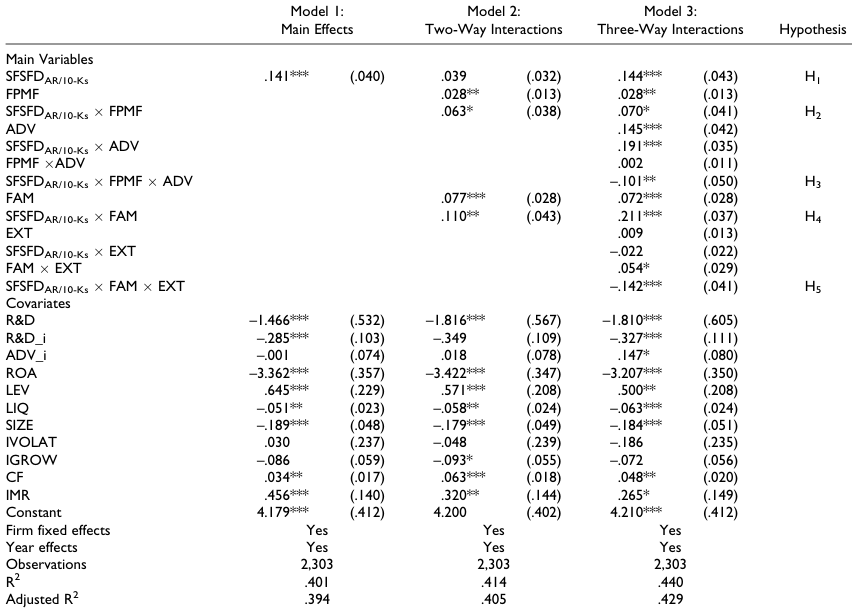

NOTE: complex table shown as an image of the PDF; the text below is a rough machine extraction and may be mis-aligned.

**extracted text (unreliable layout)**

*p < .10. **p < .05. ***p < .01. Notes: We used two-tailed significance tests. The first entry within each cell corresponds to estimated coefficients, followed by robust standard errors in parentheses. Reported effects for the main variables are standardized to facilitate interpretation of interaction effects. SFSFDAR/10-Ks ¼ size of firm’s sales force downsizing from annual reports/10-Ks (%); FPMF ¼ firm’s product market fluidity; ADV ¼ firm’s advertising intensity; FAM ¼ firm’s accruals management; EXT ¼ CEO external focus; R&D ¼ firm’s research and development expenditures to firm’s sales; R&D_i ¼ firm’s research and development dummy; ADV_i ¼ firm’s advertising dummy; ROA ¼ firm’s return on assets; LEV ¼ firm’s financial leverage; LIQ ¼ firm’s available liquidity; SIZE ¼ firm size; IVOLAT ¼ industry volatility; IGROW ¼ industry growth; CF ¼ residual term of control function model; IMR ¼ inverse Mills ratio estimated using Heckman’s selection model.

firm total stock risk (i.e., standard deviation of a firm’s daily stock returns), which is a descriptive statistic and is free of any factor model error. The results confirm our findings for all hypotheses (see Model 2, Table 8.1, Web Appendix 8).

#### Additional Analysis: The Impact of Sales Force Upsizing<sup>7</sup>

Given that investors are monitoring whether marketing expenditure cuts or increases are optimal (Mantrala et al. 2007), we use a spline specification (Greve 2003) to explore the possibility that the effect of sales force upsizing on firm-idiosyncratic risk is equivalent to (i.e., symmetric) or distinct from (i.e., asymmetric) the effect of sales force downsizing (Srinivasan et al. 2013). We construct the size of a firm’s sales force upsizing in the same way that we constructed the size of a firm’s sales force downsizing. Specifically, we operationalize the size of a firm’s sales force upsizing as the percentage change in sales force size between the year of the publication date (year t) and the year that precedes that date (year t 1), over the sales force size at year t 1, when we observe a sales force increase (i.e., positive change). For firm-year observations with sales force downsizing (i.e., negative change) or no change, we set the upsizing variable equal to zero. Accordingly, because the size of firm’s sales force downsizing is also included as a separate variable in this set of analysis, we apply a simultaneous three-level formulation—that is, sales force increase, decrease, and no change.

The additional analysis results show that the main effect of the size of a firm’s sales force upsizing on firm-idiosyncratic risk is positive and significant (see Model 3, Table 9.1, Web Appendix 9). The F-test of the estimated downsizing (gdownsizing ¼ .072, p < .01) and upsizing (gupsizing ¼ .050, p < .01) slopes reveals no statistical difference between sales force downsizing and upsizing effects on firm-idiosyncratic risk. Furthermore, none of the interactions between sales force upsizing and hypothesized moderators were significant. Importantly, all main and interaction effects concerning the size of a firm’s sales force downsizing remain significant and equivalent to our main hypothesis testing results (see Table 3), providing additional evidence of the robustness of our main findings. We discuss these findings in the “Managerial Implications” subsection.

#### Discussion

There is growing recognition that sales force downsizing constitutes a challenging marketing resource reduction with major implications for firms’ operational outcomes (Habel and Klarmann 2015; Homburg, Klarmann, and Staritz 2012). However, prior work has provided little guidance on its compelling impact on financial-market performance. Here, we develop a novel conceptual framework to (1) establish the link between the size of a firm’s sales force downsizing and firm-

idiosyncratic risk, (2) highlight investors’ screening cues that influence the impact of downsizing on risk, and (3) offer managerial levers to alleviate the effects of downsizing actions on risk.

#### Implications for Theory

We build from information economics theory to illustrate the financial-market value of strategic decisions affecting the sales force. Specifically, we propose that reducing the sales force jeopardizes customer relationships and demand opportunities, thereby increasing cash flow volatility and vulnerability— major drivers of investors’ uncertainty about a firm’s future performance and, thus, firm risk. Our work supports this argument and provides the first evidence that larger reductions of the sales force increase firm-idiosyncratic risk. This finding is important for multiple reasons. First, we expand the substantive domain of the marketing–finance interface by illuminating the role of the sales force as a strategic firm value lever, establishing new avenues that marketing influences shareholder value. Second, we broaden the theoretical framework of sales force strategy by conceptualizing the influence of sales force size changes on cash flow volatility. Establishing this theoretical mechanism should encourage future research to envision sales force decisions as financial-market investments. Theory development in this area can also provide a deeper understanding of a sales force’s financial-market value by addressing the tradeoffs and synergies of sales force actions, which accelerate, increase, or enhance the value of cash flows. Third, our findings establish the first empirical linkage between sales force downsizing and market performance metrics. This finding is especially critical given that the extant literature on sales force downsizing does not include market performance metrics (see Table 1.1, Web Appendix 1).

We also contribute to the marketing–finance literature by identifying information sources that affect investors’ uncertainty regarding future cash flows. In particular, we introduce two key investor-focused screening variables—the firm’s product market fluidity and the firm’s accruals management—as information cues that intensify market fluctuations linked to sales force downsizing. On the one hand, product market fluidity informs investors about a downsizing firm’s ability to compete in the future. A real-world instance of this phenomenon is apparent in the following quotation from an investor analyst after sales force downsizing at Novell (Bennett 2001): “My concern for the company is that others, such as Sun Microsystems and Microsoft, now have a broad range of software products that compete against Novell, and those companies have bigger sales forces. It’s going to be a real uphill battle.” Compared with measures of static competition (e.g., Herfindahl– Hirschman index), the more granular and forward-looking measure of product market fluidity improves our understanding of marketing’s strategic impact across contexts. For example, if investors uncover a high degree of rival product entries—threatening future market share—downsizing will be perceived as a riskier strategy. 7 We are thankful to the JM review team for suggesting this set of analyses.

On the other hand, our focus on firms’ accruals management as an intent-screening cue is also new to marketing, as extant research has primarily focused on investors’ uncertainty regarding unobservable quality (e.g., Joshi and Hanssens 2009). In contrast, because accruals management entails a firm behavior, we highlight investors’ uncertainty about the firm’s unobservable behavior and reasoning behind sales force downsizing. This is an important extension given that intentsignaling research in management has demonstrated adverse effects for firms that do not disclose influential information (e.g., Belogolovsky and Bamberger 2014). We find that a lack of transparency in financial statements (i.e., greater accruals management) clouds investors’ reasoning about managers’ decision to downsize the sales force, making it difficult to accurately evaluate such strategic marketing actions in financial markets. Thus, even if a sales force reduction aims to improve efficiency, investors may still feel uncertain regarding the firm’s intentions. This uncertainty may have even more distal consequences, because inaccurate capital allocation in financial markets may lead managers to respond with suboptimal internal investment decisions (Srinivasan and Hanssens 2009). The findings on both these screening cues help illustrate how investors’ evaluations influence the relationship between strategic marketing decisions and firm value. To our knowledge, we are among the first in the marketing–finance literature to identify investors’ screening cues. This opens up an exciting area of research because it provides a theoretical basis to understand which information elements can influence investors’ uncertainty and, thus, firm value. Furthermore, by examining investors’ screening cues, we answer calls for research to examine investors as “customers” in the marketing–finance interface (Hanssens, Rust, and Srivastava 2009), providing an important step forward in developing theoretical insights on the financial value of marketing strategy decisions. It is also important to note that while this focus on investors’ screening cues helps us untangle the mixed findings often associated with downsizing (see Datta et al. 2010), future research could extend our conceptualization into other marketing–finance domains by including investor cues within a screening framework.

Finally, our study extends marketing theory by offering strategies for firms to address investor uncertainty following a major firm change. Specifically, we shed light on two firmcontrolled mechanisms—the firm’s advertising intensity and CEO external focus—that can mitigate the effects of sales force layoffs on stock return volatility. Recent research has demonstrated that advertising expenditures constitute an impactful managerial action that helps signal firm quality during negative events such as product recalls (Gao et al. 2015). We broaden this theoretical rationale by showing that advertising, in the face of high rival product entries, sends a positive quality signal to investors during sales force downsizing. Furthermore, we break new theoretical ground by introducing the firm’s intent signals as a mechanism to clarify the strategic direction of the firm during a downsizing. Given that the investment community closely follows many CEOs for insights into their thinking

(Yadav, Prabhu, and Chandy 2007), the intentions signaled through MD&A reports should have a critical impact on how marketing resource changes are interpreted. Our findings support this notion by showing that CEO external focus, in the face of high accruals management, provides clarity to investors during sales force downsizing.

#### Managerial Implications

Our findings deepen managers’ understanding on the relevance of sales force decisions for Wall Street. Tuli and Bharadwaj (2009) point out that idiosyncratic risk is a key metric used by financial analysts to issue the risk ratings of stocks. Idiosyncratic risk also matters to investors because it lowers subsequent risk-adjusted returns. As a result, identifying sales force changes that influence idiosyncratic risk is important because managers can use the sales force as a lever within the firm’s risk-management and financing strategy. For example, managers can quantify the economic significance (i.e., cost of capital) of downsizing by including risk in their decision metrics. From our study, a one-standard-deviation decrease in sales force size (7.5%) increases daily firm-idiosyncratic risk by .076%. Relative to the variability of idiosyncratic risk (SD ¼ 1.141), this represents a 6.7% influence, which is substantial enough to significantly influence a firm’s cost of capital—a significant burden for most firms (Rego, Billett, and Morgan 2009). To illustrate, previous research in finance finds that a 1% increase in daily idiosyncratic risk increases annualized corporate bond yields by 222 basis points (Campbell and Taksler 2003), meaning that a 7.5% sales force downsizing would translate into an increase of 17 basis points (.076% 222) in yearly borrowing rates for the firm. Moreover, our counterfactual analysis shows that if a downsizing firm elected not to reduce its sales force, it would have avoided a .46% increase in risk (i.e., an increase of 102 basis points in yearly borrowing rates). Managers can use these findings to make more informed resource allocation decisions for managing cost of capital as well as other downstream effects of firm-idiosyncratic risk. In particular, our findings suggest that sales force management decisions driven by cost management concerns actually have unintended consequences that will offset any potential cost efficiency gains. This is because laying off the sales force increases the firm’s cost of capital. To explore this issue, we collected wage data for the sales roles that were most represented in our sample—that is, sales roles in advertising, insurance, financial services, manufacturing, other services, and sales engineering (Bureau of Labor Statistics 2017). Using a mean annual wage of $68,247 for salespeople across our sample in these roles, we find that a one-standard-deviation reduction (566 salespeople) would provide $38.6 million in short-term cost savings. As mentioned previously, a onestandard-deviation sales force reduction translates into a 17- basis points increase in cost of borrowing. Thus, for the average firm in our sample, with total liabilities equal to $10,016 million, the 17 basis points translate to an increase of $17.03 million in financial expenses. As such, the $38.6 million in

cost savings are actually only $21.57 million, without taking into account other important downstream effects (i.e., cost of equity). Obviously, managers who make decisions about sales force changes without considering these nuanced effects would significantly overestimate cost savings from sales force layoffs. Accordingly, marketing leaders are advised to communicate the expected increase in cost of capital with other C-suite leaders (e.g., CEOs, chief financial officers) as important input into management decision making related to sales force layoffs.

We also urge firm leaders to conduct rigorous research to ascertain investor perceptions about future product market competition by utilizing the publicly available data on the product market fluidity metric (see Hoberg, Phillips, and Prabhala 2014). This data can help leaders ascertain whether there are cues that signal an inability to differentiate from competition, and, thus, map out specific strategies to mitigate risk during downsizing. In particular, marketing leaders can coordinate advertising campaigns during sales force downsizing to address investors’ concerns, especially when the firm faces high levels of rapid changes in its product market. Using data from our sample, we find that, for firms experiencing high rival product entries and low advertising spending, a 7.5% sales force reduction increases risk by .20%, versus only .10% for firms experiencing high rival product entries and high advertising spending. This translates into a savings of 22 basis points in borrowing costs (44 vs. 22). Interestingly, the risk-mitigating role of advertising fades when product fluidity is not high, indicating that there are specific conditions when advertising offers a tangible managerial benefit.

Our findings also suggest that CEOs must focus on the intent signals communicated through MD&As, given that such signals have a critical impact on how downsizing is interpreted. Specifically, elaboration of a strategic focus directed at external entities (e.g., customers, competitors) through the MD&A is a critical process that sends investors key information that helps them ascertain the current and future state of cash flows, thereby dampening their uncertainty linked to downsizing in the face of high accruals management. In our sample, for instance, we find that for firms with greater accruals management but low CEO external focus, a 7.5% sales force reduction increases risk by .19% (42 basis points), versus a risk increase of only .13% (29 basis points) for firms with high CEO external focus. These findings are noteworthy and confirm prior work suggesting that the investment community closely follows CEOs for insights into their thinking (Yadav, Prabhu, and Chandy 2007).

Finally, we highlight to managers that while marketing investments (e.g., sales force upsizing) are often implicitly assumed to increase sales, expected cash flows, and consequently shareholder wealth, this intuition is not always valid (Rao and Bharadwaj 2008). In contrast, our findings indicate that upsizing increases idiosyncratic risk, albeit through different mechanisms than downsizing. Specifically, results from our additional analysis indicate that a 7.5% increase in sales force size increases idiosyncratic risk by .050% (11 basis points). Yet these findings also show that none of the interactions for sales

force upsizing were significant, indicating that upsizing influences risk through different mechanisms than downsizing. This is because marketing investments often change the probability distribution of a firm’s sales revenues and, thus, its working capital (cash) needs, which together determine the expected cash flows for investors (Rao and Bharadwaj 2008). We therefore caution managers to account for the influence of upsizing on risk and recognize that the signaling cues we propose for downsizing do not mitigate risk when growing the sales force.

#### Limitations and Future Research Directions

Our study is subject to some limitations that present fruitful avenues for future research. First, we do not specify causes of sales force downsizing, yet these causes may bias investors’ evaluations of downsizing. Future research could delineate between different drivers of sales force downsizing (e.g., economic environment, firm strategy) to understand the market performance tied to these strategic decisions. Second, we studied firms in the Selling Power list, which limits our findings to firms with larger sales forces. Thus, future research should confirm the robustness of our findings for firms with smaller sales forces. Third, while our study substantiates the effect of sales force upsizing on firm risk, there is potential for future research to identify signaling cues that mitigate upsizing’s influence. Drawing on the results of our additional analysis, we believe that the signaling mechanisms that help reduce investors’ uncertainty from upsizing are different from those for downsizing and may, for instance, refer to corporate governance or cost efficiency strategies. Fourth, while we draw on prior theoretical work (e.g., Connelly et al. 2011) to focus on firm signals that mitigate investors’ screening cues (i.e., threeway interactions), it would be useful to understand which firm signals act independently of investor evaluations (i.e., as twoway interactions) to influence the relationship between sales force size changes and firm risk. Finally, future research should examine the differences in firm risk between early and later rounds of downsizing, given that a single downsizing decision in a given year may involve multiple rounds of downsizing.<sup>8</sup> In conclusion, we hope that our work will spark scholarly interest for future research in this vital area of marketing practice.

Acknowledgments

The authors thank the JM review team for the many insightful suggestions that have greatly improved this article. The authors also thank Mike Ahearne, Rob Palmatier, Murali Mantrala, Andrew Petersen, John Hulland, and Kyriakos Kyriakopoulos for their useful feedback on prior versions of this article that helped them improve their work. The authors also thank Bill McDonald, Dan Albertson, and Shane Underwood for their guidance in selecting the text analysis software employed in this study.

8 We are thankful to an anonymous reviewer for contributing this insightful suggestion.

Author Contributions

All authors contributed equally, and their names appear in reverse alphabetical order.

Area Editor

Christine Moorman served as area editor for this article.

Declaration of Conflicting Interests

The author(s) declared no potential conflicts of interest with respect to the research, authorship, and/or publication of this article.

Funding

The author(s) received no financial support for the research, authorship, and/or publication of this article.

References

Belogolovsky, Elena, and Peter A. Bamberger (2014), “Signaling in

Secret: Pay for Performance and the Incentive and Sorting Effects of Pay Secrecy,” Academy of Management Journal, 57 (6), 1706–33. Bennett, Amy (2001), “Novell Takes Investment Loss, Sees Revenue

Grow,” ITworld (November 30), http://www.itworld.com/article/ 2793749/networking/novell-takes-investment-loss–sees-revenuegrow.html. Bharadwaj, Sundar G., Kapil R. Tuli, and Andre Bonfer (2011), “The

Impact of Brand Quality on Shareholder Wealth,” Journal of Marketing, 75 (5), 88–104. Boone, Audra L., Ioannis V. Floros, and Shane A. Johnson (2016),

“Redacting Proprietary Information at the Initial Public Offering,” Journal of Financial Economics, 120 (1), 102–23. Budros, Art (2000), “Organizational Types and Organizational Inno-

vation: Downsizing Among Industrial, Financial, and Utility Firms,” Sociological Forum, 15 (2), 273–306. Bureau of Labor Statistics (2013), “Mass Layoff Statistics,” (accessed

September 21, 2016), http://www.bls.gov/mls/mlbfbpt1_20131. htm. Bureau of Labor Statistics (2017), “Occupational Employment

Statistics,” (accessed December 11, 2017), https://www.bls.gov/ oes/tables.htm. Campbell, John Y., Martin Lettau, Burton G. Malkiel, and Yexiao Xu

(2001), “Have Individual Stocks Become More Volatile? An Empirical Exploration of Idiosyncratic Risk,” Journal of Finance, 56 (1), 1–43. Campbell, John Y., and Glen B. Taksler (2003), “Equity Volatility and

Corporate Bond Yields,” Journal of Finance, 58 (6), 2321–50. Colletti, Jerome A., and Lawrence B. Chonko (1997), “Change Man-

agement Initiatives: Moving Sales Organizations from Obsolescence to High Performance,” Journal of Personal Selling & Sales Management, 17 (2), 1–30. Connelly, Brian L., S. Trevis Certo, R. Duane Ireland, and Christopher

R. Reutzel (2011), “Signaling Theory: A Review and Assessment,” Journal of Management, 37 (1), 39–67. Datta, Deepak K., James P. Guthrie, Dynah Basuil, and Alnakrita

Pandey (2010), “Causes and Effects of Employee Downsizing: A Review and Synthesis,” Journal of Management, 36 (1), 281–348.

Dechow, Patricia M., Richard G. Sloan, and Amy P. Sweeney (1995),

“Detecting Earnings Management,” Accounting Review, 70 (2), 193–225. Devers, Cynthia E., Alberta A. Cannella Jr., Gregory P. Reilly, and

Michele E. Yoder (2007), “Executive Compensation: A Multidisciplinary Review of Recent Developments,” Journal of Management, 33 (6), 1016–72. Edwards, Jim (2011), “Yes, There Will Be More Layoffs at Pfizer, as

These Numbers Show,” (June 15), http://www.cbsnews.com/news/ yes-there-will-be-more-layoffs-at-pfizer-as-these-numbers-show/. Eggers, J. P., and Sarah Kaplan (2009), “Cognition and Renewal:

Comparing CEO and Organizational Effects on Incumbent Adaptation to Technical Change,” Organization Science, 20 (2), 461–77. Ferreira, Miguel A., and Paula A. Laux (2007), “Corporate Govern-

ance, Idiosyncratic Risk, and Information Flow,” Journal of Finance, 62 (2), 951–89. Frieder, Laura, and Avanidhar Subrahmanyam (2005), “Brand Percep-

tions and the Market for Common Stock,” Journal of Financial and Quantitative Analysis, 40 (1), 57–85. Gao, Haibing, Jinhong Xie, Qi Wang, and Kenneth C. Wilbur (2015),

“Should Ad Spending Increase or Decrease Before a Recall Announcement? The Marketing–Finance Interface in Product- Harm Crisis Management,” Journal of Marketing, 79 (5), 80–99. Greve, Henrich R. (2003), “A Behavioral Theory of R&D Expendi-

tures and Innovations: Evidence from Shipbuilding,” Academy of Management Journal, 46 (6), 685–702. Gruca, Thomas S., and Lopo R. Rego (2005), “Customer Satisfaction,

Cash Flow, and Shareholder Value,” Journal of Marketing, 69 (3), 1–13. Habel, Johannes, and Martin Klarmann (2015), “Customer Reactions

to Downsizing: When and How Is Satisfaction Affected?” Journal of the Academy of Marketing Science, 43 (6), 768–89. Han, Kyuhong, Vikas Mittal, and Yan Zhang (2017), “Relative Stra-

tegic Emphasis and Firm Idiosyncratic Risk: The Moderating Role of Relative Performance and Demand Instability,” Journal of Marketing, 81 (4), 25–44. Hanssens, Dominique M., Roland T. Rust, and Rajendra Srivastava

(2009), “Marketing Strategy and Wall Street: Nailing Down Marketing’s Impact,” Journal of Marketing, 73 (6), 115–18. Hoberg, Gerard, Gordon Phillips, and Nagpurnanand Prabhala (2014),

“Product Market Threats, Payouts, and Financial Flexibility,” Journal of Finance, 69 (1), 293–324. Homburg, Christian, Martin Klarmann, and Sabine Staritz (2012),

“Customer Uncertainty Following Downsizing: The Effects of Extent of Downsizing and Open Communication,” Journal of Marketing, 76 (3), 112–30. Hutton, Amy P., Alan J. Marcus, and Hassan Tehranian (2009),

“Opaque Financial Reports, R<sup>2</sup>, and Crash Risk,” Journal of Financial Economics, 94 (1), 67–86. Joshi, Amit, and Dominique Hanssens (2009), “Movie Advertising

and the Stock Market Valuation of Studios: A Case of ‘Great Expectations’?” Marketing Science, 28 (2), 239–50. Kim, MinChung, and Leigh M. McAlister (2011), “Stock Market

Reaction to Unexpected Growth in Marketing Expenditure:

Negative for Sales Force, Contingent on Spending Level for Advertising,” Journal of Marketing, 75 (4), 68–85. Kothari, S. P., Natalie Mizik, and Sugata Roychowdhury (2015),

“Managing for the Moment: The Role of Earnings Management via Real Activities Versus Accruals in SEO Valuation,” Accounting Review, 91 (2), 559–86. Kumar, V., Sarang Sunder, and Robert P. Leone (2014), “Measuring

and Managing a Salesperson’s Future Value to the Firm,” Journal of Marketing Research, 51 (5), 591–608. Lee, Ju-Yeon, Shrihari Sridhar, and Robert W. Palmatier (2017), “The

Effect of Firms’ Structural Designs on Advertising and Personal Selling Returns,” International Journal of Research in Marketing, 34 (1), 173–93. Luo, Xueming, and C. B. Bhattacharya (2009), “The Debate over

Doing Good: Corporate Social Performance, Strategic Marketing Levers, and Firm-Idiosyncratic Risk,” Journal of Marketing, 73 (6), 198–213. Mantrala, Murali K., Prasad A. Naik, Shrihari Sridhar, and Esther

Thorson (2007), “Uphill or Downhill? Locating the Firm on a Profit Function,” Journal of Marketing, 71 (2), 26–44. Minton, Bernadette A., and Catherine Schrand (1999), “The Impact of

Cash Flow Volatility on Discretionary Investment and the Costs of Debt and Equity Financing,” Journal of Financial Economics, 54 (3), 423–60. Mizik, Natalie (2010), “The Theory and Practice of Myopic Manage-

ment,” Journal of Marketing Research, 47 (4), 594–611. Osborne, David J., Charles I. Stubbart, and Arkalgud Ramaprasad

(2001), “Strategic Groups and Competitive Enactment: A Study of Dynamic Relationships Between Mental Models and Performance,” Strategic Management Journal, 22 (5), 435–54. Palmatier, Robert W., Rajiv P. Dant, Dhruv Grewal, and Kenneth

R. Evans (2006), “Factors Influencing the Effectiveness of Relationship Marketing: A Meta-Analysis,” Journal of Marketing, 70 (4), 136–53. Petrin, Amil, and Kenneth Train (2010), “A Control Function

Approach to Endogeneity in Consumer Choice Models,” Journal of Marketing Research, 47 (1), 3–13. Raithel, Sascha, Marko Sarstedt, Sebastian Scharf, and Manfred

Schwaiger (2012), “On the Value Relevance of Customer Satisfaction: Multiple Drivers and Multiple Markets,” Journal of the Academy of Marketing Science, 40 (4), 509–25. Rao, Ramesh K. S., and Neeraj Bharadwaj (2008), “Marketing Initia-

tives, Expected Cash Flows, and Shareholders’ Wealth,” Journal of Marketing, 72 (1), 16–26.

Rego, Lopo L., Matthew T. Billett, and Neil A. Morgan (2009),

“Consumer-Based Brand Equity and Firm Risk,” Journal of Marketing, 73 (6), 47–60. Rubera, Gaia, and Ahmet H. Kirca (2012), “Firm Innovativeness and

Its Performance Outcomes: A Meta-Analytic Review and Theoretical Integration,” Journal of Marketing, 76 (3), 130–47. Saboo, Alok, and Rajdeep Grewal (2013), “Stock Market Reactions to

Customer and Competitor Orientations: The Case of Initial Public Offerings,” Marketing Science, 32 (1), 70–88. Sethuraman, Raj, Gerard. J. Tellis, and Richard A. Briesch (2011),

“How Well Does Advertising Work? Generalizations from Meta- Analysis of Brand Advertising Elasticities,” Journal of Marketing Research, 48 (3), 457–71. Srinivasan, Raji, Shrihari Sridhar, Sriram Narayanan, and Debika Sihi

(2013), “Effects of Opening and Closing Stores on Chain Retailer Performance,” Journal of Retailing, 89 (2), 126–39. Srinivasan, Shuba, and Dominque M. Hanssens (2009), “Marketing

and Firm Value: Metrics, Methods, Findings, and Future Directions,” Journal of Marketing Research, 46 (3), 293–312. Srivastava, Rajendra K., Tasadduq A. Shervani, and Liam Fahey

(1998), “Market-Based Assets and Shareholder Value: A Framework for Analysis,” Journal of Marketing, 62 (1), 2–18. Stiglitz, Joseph E. (2000), “The Contributions of the Economics of

Information to Twentieth Century Economics,” Quarterly Journal of Economics, 115 (4), 1441–78. Thomaz, Felipe, and Vanitha Swaminathan (2015), “What Goes

Around Comes Around: The Impact of Marketing Alliances on Firm Risk and the Moderating Role of Network Density,” Journal of Marketing, 79 (5), 63–79. Tuli, Kapil R., and Sundar G. Bharadwaj (2009), “Customer Satisfac-

tion and Stock Returns Risk,” Journal of Marketing, 73 (6), 184–97. Wooldridge, Jeffrey M. (2002), Econometric Analysis of Cross Sec-

tion and Panel Data. Cambridge, MA: MIT Press. Yadav, Manjit S., Jaideep C. Prabhu, and Rajesh K. Chandy (2007),

“Managing the Future: CEO Attention and Innovation Outcomes,” Journal of Marketing, 71 (4), 84–101. Zhang, Yan, and Margarethe F. Wiersema (2009), “Stock Market

Reaction to CEO Certification: The Signaling Role of CEO Background,” Strategic Management Journal, 30 (7), 693–710. Zoltners, Andris A., Prabhakant Sinha, and Sally E. Lorimer (2018),

“How to Downsize Your Sales Force,” Harvard Business Review (April 12), https://hbr.org/2018/04/how-to-downsize-your-salesforce.